# Automatic report for a Completely Randomized Design (CRD)

International Potato Center

June 23, 2016

# 1. Model specification and data description

There are data from 27 genotypes, evaluated using a completely randomized design. The statistical model is
$$y_{ij} = \mu + \tau_i + \epsilon_{ij}$$
where

- $y_{ij}$ is the observed response with genotype $i$ and replication $j$.
- $\mu$ is the mean response over all genotypes and replications.
- $\tau_i$ is the effect for genotype $i$.
- $\epsilon_{ij}$ is the error term.

In this model we assume that the errors are independent and have a normal distribution with common variance, that is, $\epsilon_{ij} \sim N(0,\sigma_{\epsilon}^2)$.

# 2. Analysis for trait Weight of vines measuring kg per plot

## 2.1. ANOVA

You have fitted a linear model for a CRD. The ANOVA table for your model is:

```
## Analysis of Variance Table
##
## Response: "Weight of vines measuring kg per plot"
##               Df Sum Sq Mean Sq F value    Pr(>F)
## germplasmName 26 7649.4  294.21  2.7246 0.0009425 ***
## Residuals     54 5831.0  107.98
## ---
## Signif. codes:  0 '***' 0.001 '**' 0.01 '*' 0.05 '.' 0.1 ' ' 1
```

The coefficient of variation for this experiment is 44.61%. The p-value for genotypes is 0.0009425 which is significant at the 5% level.

## 2.2. Assumptions

Don’t forget the assumptions of the model. It is supposed that the errors are independent with a normal distribution and with the same variance for all the genotypes. The following residuals plots must help you evaluate this:

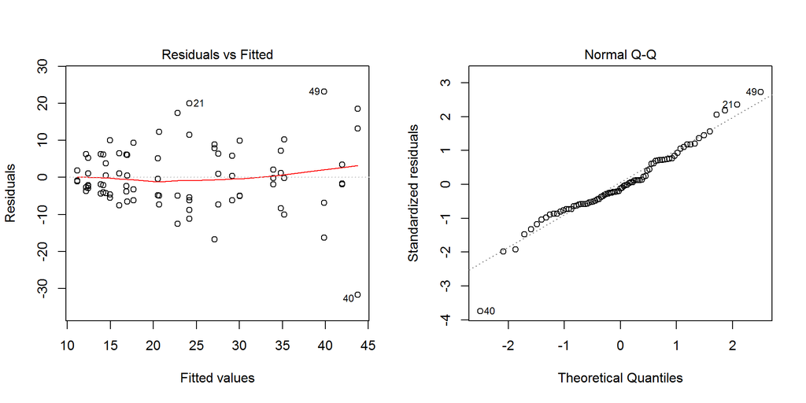

Any trend in the residuals in the left plot would violate the assumption of independence while a trend in the variability of the residuals –for instance a funnel shape– suggests heterogeneity of variances. Departures from the theoretical normal line on the right plot are symptoms of lack of normality.

## 2.3. Genotype means

Below are the sorted means for each genotype with letters indicating if there are significant differences using the multiple comparisons method of Tukey at the 5% level.

```
##             trt    means M
## 1  MGSG 1015-2  43.76667 a
## 2  MGSG 1051-1  41.93333 a
## 3  MGSG 1032-3  39.83333 a
## 4  MGSG 1005-17 35.20000 a
## 5  MGSG 1007-9  34.83333 a
## 6  MGSG 1015-17 33.93333 a
## 7  Chingova     30.03333 a
## 8  MGSG 1065-4  29.16667 a
## 9  MGSG 1003-27 27.56667 a
## 10 MGSG 1006-9  27.10000 a
## 11 MGSG 1006-7  24.20000 a
## 12 MGSG 1008-8  24.16667 a
## 13 MGSG 1068-1  22.80000 a
## 14 MGSG 1004-2  20.66667 a
## 15 MGSG 1010-10 20.50000 a
## 16 MGSG 1061-3  17.70000 a
## 17 MGSG 1009-3  16.96667 a
## 18 Resisto      16.86667 a
## 19 MGSG 1012-9  16.03333 a
## 20 MGSG 1004-27 14.96667 a
## 21 MGSG 1010-4  14.46667 a
## 22 MGSG 1002-49 14.16667 a
## 23 Jonathan     13.86667 a
## 24 MGSG 1001-7  12.43333 a
## 25 MGSG 1011-5  12.43333 a
## 26 MGSG 1001-36 12.16667 a
## 27 MGSG 1007-13 11.13333 a
```

## 2.4. Variance components

Below are the variance components for this model, under the assumption that genotypes are random. Here the model is fitted using REML.

```
##                Variance  Std.Dev.
## germplasmName  62.07585  7.878823
## Residual      107.98074 10.391378
```